# Real data: RV144 and HVTN078 vaccine trials

```r
# Parameters -------------------------------------------------------------------
RUN_DIR <- Sys.getenv("VACCINE_RUN_DIR", "runs/2026-11-03_realdata/vaccine") # output of 30_analyse-vaccine.R, relative to the repo root
PROCESSED <- "data/processed" # 20_prepare-rv144.R, 21_prepare-hvtn078.R
DATASETS <- c("rv144", "hvtn078")
```

```r
suppressPackageStartupMessages({
  library(dplyr)
  library(forcats)
  library(ggplot2)
  library(purrr)
  library(readr)
  library(stringr)
  library(tidyr)
})
theme_set(theme_bw(base_size = 8))
root <- here::here()
read_ds <- \(f, ds = DATASETS) map(set_names(ds), \(d) {
  p <- file.path(root, RUN_DIR, d, f)
  if (file.exists(p)) read_tsv(p, show_col_types = FALSE)
}) |> compact() |> list_rbind(names_to = "dataset")
METHOD_COLOURS <- c(m1dm = "#D55E00", m1 = "#E69F00", C0 = "#CC79A7", COMPASS = "#0072B2",
                    polyICSFlow_clipped = "#009E73", polyICSFlow_unclipped = "#999999")
method_of <- \(x) fct(case_when(
  str_starts(x, "m1dm") ~ "m1dm", str_starts(x, "m1_") ~ "m1", str_starts(x, "C0") ~ "C0", str_starts(x, "COMPASS") ~ "COMPASS",
  str_detect(x, "unclipped") ~ "polyICSFlow_unclipped", str_starts(x, "polyICSFlow") ~ "polyICSFlow_clipped"), levels = names(METHOD_COLOURS))
```

## Data checks

Both tables are COMPASS-filtered (removed patterns were folded into the all-negative count), so the positive-cell frequencies below are lower bounds.

```r
map(DATASETS, \(d) read_tsv(file.path(root, PROCESSED, d, "prep_log.tsv"), show_col_types = FALSE) |>
      mutate(across(everything(), as.character)) |> pivot_longer(everything()) |> mutate(dataset = d)) |>
  list_rbind() |> pivot_wider(names_from = dataset, values_from = value) |> knitr::kable()
```

| name | rv144 | hvtn078 |
| --- | --- | --- |
| markers_native | TNFa,IFNg,IL4,IL2,CD154,IL17a | TNFa,IFNg,IL4,MIP1B,IL2,CD154,CD107a |
| markers_kept | IFNg,IL2,TNFa,CD154,IL4 | IFNg,IL2,TNFa,CD154,CD107a |
| markers_dropped | IL17a | IL4,MIP1B |
| patterns_native_kept_by_compass | 24 | 26 |
| patterns_native_possible | 64 | 128 |
| patterns_reduced_possible | 32 | 32 |
| patterns_reduced_nonzero | 21 | 16 |
| n_donors | 262 | 76 |
| donors_removed_no_control | 0 | 0 |
| donors_with_na_metadata | 36 | 0 |
| n_vaccine | 226 | 71 |
| n_placebo | 36 | 5 |
| n_vaccine_infected | 38 | NA |
| median_allneg_fraction_stim | 0.997253709230808 | 0.997377537895809 |
| rowsums_equal_counts | TRUE | TRUE |
| min_N | 5141 | 45415 |
| median_N | 54905 | 112090.5 |
| caveat | COMPASS-filtered tables: removed patterns’ cells folded into all-negative; not exact partitions | COMPASS-filtered tables: removed patterns’ cells folded into all-negative; not exact partitions |

```r
read_ds("epsilon_check.tsv") |> knitr::kable(digits = 6)
```

| dataset | eps | N_min | N_median | N_max | inv_N_at_median | inv_N_at_min | eps_over_inv_N_min | expected_cells_at_eps_median_N |
| --- | --- | --- | --- | --- | --- | --- | --- | --- |
| rv144 | 1e-04 | 5141 | 54905.0 | 117034 | 1.8e-05 | 0.000195 | 0.5141 | 5.49050 |
| hvtn078 | 1e-04 | 45415 | 112090.5 | 292087 | 9.0e-06 | 0.000022 | 4.5415 | 11.20905 |

## ROC curves, vaccine vs placebo

Each curve ranks donors by a method’s score; the diagonal is chance, and HVTN078 has only five placebo recipients.

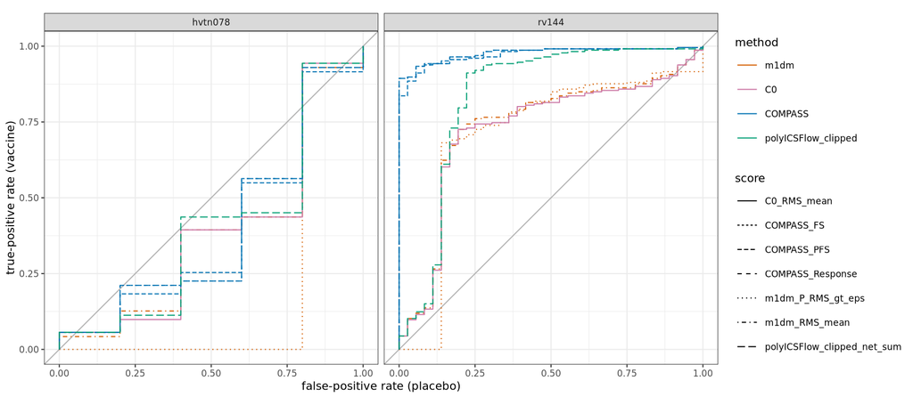

```r
focus <- c("m1dm_P_RMS_gt_eps", "m1dm_RMS_mean", "C0_RMS_mean", "COMPASS_FS", "COMPASS_PFS", "COMPASS_Response",
           "polyICSFlow_clipped_net_sum")
read_ds("roc_curves.tsv") |>
  filter(score_name %in% focus) |>
  mutate(method = method_of(score_name)) |>
  ggplot(aes(fpr, tpr, colour = method, linetype = score_name)) +
  geom_abline(colour = "grey70") +
  geom_step() +
  scale_colour_manual(values = METHOD_COLOURS) +
  facet_wrap(~dataset) +
  coord_equal() +
  labs(x = "false-positive rate (placebo)", y = "true-positive rate (vaccine)", linetype = "score")
```

## AUC with bootstrap CI

The CI resamples donors within vaccine and placebo (2000 replicates); CCS rows are experimental and carry no conclusion.

```r
auc <- read_ds("auc.tsv")
auc |>
  transmute(dataset, score_name, experimental, AUC = sprintf("%.3f (%.3f, %.3f)", auc, lower, upper), n_case, n_noncase) |>
  knitr::kable()
```

| dataset | score_name | experimental | AUC | n_case | n_noncase |
| --- | --- | --- | --- | --- | --- |
| rv144 | m1dm_P_RMS_gt_eps | FALSE | 0.755 (0.672, 0.828) | 226 | 36 |
| rv144 | m1dm_RMS_mean | FALSE | 0.732 (0.638, 0.816) | 226 | 36 |
| rv144 | m1dm_P_RMS_gt_eps1e-3 | FALSE | 0.782 (0.690, 0.862) | 226 | 36 |
| rv144 | m1dm_CPS_mean | FALSE | 0.921 (0.875, 0.958) | 226 | 36 |
| rv144 | m1dm_P_CPS_gt_eps | FALSE | 0.922 (0.886, 0.954) | 226 | 36 |
| rv144 | m1dm_CCS_mean | TRUE | 0.810 (0.749, 0.864) | 226 | 36 |
| rv144 | m1dm_P_CCS_gt_eps | TRUE | 0.919 (0.870, 0.958) | 226 | 36 |
| rv144 | m1_P_RMS_gt_eps | FALSE | 0.793 (0.719, 0.854) | 226 | 36 |
| rv144 | m1_RMS_mean | FALSE | 0.778 (0.698, 0.844) | 226 | 36 |
| rv144 | m1_P_RMS_gt_eps1e-3 | FALSE | 0.829 (0.750, 0.893) | 226 | 36 |
| rv144 | m1_CPS_mean | FALSE | 0.829 (0.731, 0.909) | 226 | 36 |
| rv144 | m1_P_CPS_gt_eps | FALSE | 0.707 (0.627, 0.789) | 226 | 36 |
| rv144 | m1_CCS_mean | TRUE | 0.825 (0.725, 0.908) | 226 | 36 |
| rv144 | m1_P_CCS_gt_eps | TRUE | 0.801 (0.712, 0.876) | 226 | 36 |
| rv144 | C0_P_RMS_gt_eps | FALSE | 0.752 (0.667, 0.825) | 226 | 36 |
| rv144 | C0_RMS_mean | FALSE | 0.725 (0.630, 0.809) | 226 | 36 |
| rv144 | C0_P_RMS_gt_eps1e-3 | FALSE | 0.775 (0.681, 0.855) | 226 | 36 |
| rv144 | C0_CPS_mean | FALSE | 0.841 (0.775, 0.902) | 226 | 36 |
| rv144 | C0_P_CPS_gt_eps | FALSE | 0.833 (0.773, 0.891) | 226 | 36 |
| rv144 | C0_CCS_mean | TRUE | 0.648 (0.575, 0.716) | 226 | 36 |
| rv144 | C0_P_CCS_gt_eps | TRUE | 0.838 (0.773, 0.895) | 226 | 36 |
| rv144 | COMPASS_FS | FALSE | 0.977 (0.959, 0.991) | 226 | 36 |
| rv144 | COMPASS_PFS | FALSE | 0.972 (0.952, 0.989) | 226 | 36 |
| rv144 | COMPASS_Response | FALSE | 0.977 (0.959, 0.991) | 226 | 36 |
| rv144 | COMPASS_Response2 | FALSE | 0.979 (0.959, 0.993) | 226 | 36 |
| rv144 | polyICSFlow_clipped_net_sum | FALSE | 0.834 (0.734, 0.920) | 226 | 36 |
| rv144 | polyICSFlow_unclipped_net_sum | FALSE | 0.728 (0.633, 0.812) | 226 | 36 |
| hvtn078 | m1dm_P_RMS_gt_eps | FALSE | 0.428 (0.261, 0.690) | 71 | 5 |
| hvtn078 | m1dm_RMS_mean | FALSE | 0.386 (0.135, 0.670) | 71 | 5 |
| hvtn078 | m1dm_P_RMS_gt_eps1e-3 | FALSE | 0.406 (0.206, 0.639) | 71 | 5 |
| hvtn078 | m1dm_CPS_mean | FALSE | 0.330 (0.149, 0.507) | 71 | 5 |
| hvtn078 | m1dm_P_CPS_gt_eps | FALSE | 0.341 (0.176, 0.531) | 71 | 5 |
| hvtn078 | m1dm_CCS_mean | TRUE | 0.383 (0.166, 0.634) | 71 | 5 |
| hvtn078 | m1dm_P_CCS_gt_eps | TRUE | 0.386 (0.183, 0.609) | 71 | 5 |
| hvtn078 | m1_P_RMS_gt_eps | FALSE | 0.487 (0.338, 0.724) | 71 | 5 |
| hvtn078 | m1_RMS_mean | FALSE | 0.349 (0.110, 0.645) | 71 | 5 |
| hvtn078 | m1_P_RMS_gt_eps1e-3 | FALSE | 0.365 (0.155, 0.617) | 71 | 5 |
| hvtn078 | m1_CPS_mean | FALSE | 0.369 (0.124, 0.645) | 71 | 5 |
| hvtn078 | m1_P_CPS_gt_eps | FALSE | 0.417 (0.254, 0.670) | 71 | 5 |
| hvtn078 | m1_CCS_mean | TRUE | 0.341 (0.121, 0.620) | 71 | 5 |
| hvtn078 | m1_P_CCS_gt_eps | TRUE | 0.338 (0.124, 0.575) | 71 | 5 |
| hvtn078 | C0_P_RMS_gt_eps | FALSE | 0.423 (0.254, 0.687) | 71 | 5 |
| hvtn078 | C0_RMS_mean | FALSE | 0.386 (0.135, 0.679) | 71 | 5 |
| hvtn078 | C0_P_RMS_gt_eps1e-3 | FALSE | 0.400 (0.197, 0.632) | 71 | 5 |
| hvtn078 | C0_CPS_mean | FALSE | 0.335 (0.144, 0.538) | 71 | 5 |
| hvtn078 | C0_P_CPS_gt_eps | FALSE | 0.339 (0.141, 0.552) | 71 | 5 |
| hvtn078 | C0_CCS_mean | TRUE | 0.532 (0.299, 0.749) | 71 | 5 |
| hvtn078 | C0_P_CCS_gt_eps | TRUE | 0.366 (0.197, 0.544) | 71 | 5 |
| hvtn078 | COMPASS_FS | FALSE | 0.397 (0.124, 0.685) | 71 | 5 |
| hvtn078 | COMPASS_PFS | FALSE | 0.392 (0.124, 0.676) | 71 | 5 |
| hvtn078 | COMPASS_Response | FALSE | 0.397 (0.124, 0.685) | 71 | 5 |
| hvtn078 | COMPASS_Response2 | FALSE | 0.383 (0.113, 0.665) | 71 | 5 |
| hvtn078 | polyICSFlow_clipped_net_sum | FALSE | 0.400 (0.144, 0.690) | 71 | 5 |
| hvtn078 | polyICSFlow_unclipped_net_sum | FALSE | 0.377 (0.130, 0.665) | 71 | 5 |

```r
read_ds("auc_diff.tsv") |> knitr::kable(digits = 3)
```

| dataset | a | b | diff | lower | upper |
| --- | --- | --- | --- | --- | --- |
| rv144 | m1dm_RMS_mean | COMPASS_FS | -0.245 | -0.336 | -0.164 |
| rv144 | m1dm_RMS_mean | COMPASS_PFS | -0.240 | -0.335 | -0.158 |
| rv144 | m1dm_P_RMS_gt_eps | COMPASS_Response | -0.221 | -0.303 | -0.149 |
| rv144 | m1dm_RMS_mean | m1_RMS_mean | -0.045 | -0.107 | 0.005 |
| rv144 | m1dm_RMS_mean | C0_RMS_mean | 0.007 | 0.001 | 0.015 |
| rv144 | m1dm_RMS_mean | polyICSFlow_clipped_net_sum | -0.102 | -0.144 | -0.060 |
| hvtn078 | m1dm_RMS_mean | COMPASS_FS | -0.011 | -0.121 | 0.107 |
| hvtn078 | m1dm_RMS_mean | COMPASS_PFS | -0.006 | -0.121 | 0.121 |
| hvtn078 | m1dm_P_RMS_gt_eps | COMPASS_Response | 0.031 | -0.132 | 0.182 |
| hvtn078 | m1dm_RMS_mean | m1_RMS_mean | 0.037 | -0.017 | 0.099 |
| hvtn078 | m1dm_RMS_mean | C0_RMS_mean | 0.000 | -0.020 | 0.023 |
| hvtn078 | m1dm_RMS_mean | polyICSFlow_clipped_net_sum | -0.014 | -0.051 | 0.017 |

## False positives among placebo recipients

Each method is read at its conventional rule: P(RMS > eps) above 0.95, COMPASS Response above 0.5, clipped polyICSFlow net above 0.

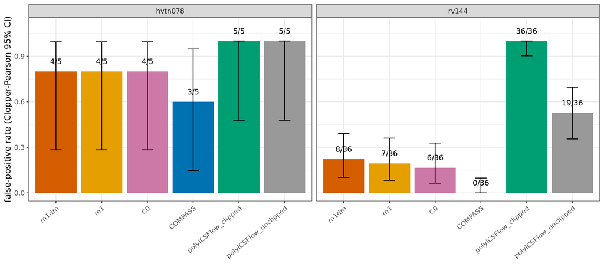

```r
fpr <- read_ds("fpr.tsv")
fpr |>
  mutate(method = fct(method, levels = names(METHOD_COLOURS))) |>
  ggplot(aes(method, fpr, fill = method)) +
  geom_col() +
  geom_errorbar(aes(ymin = fpr_lower, ymax = fpr_upper), width = 0.25) +
  geom_text(aes(label = sprintf("%d/%d", n_false_positive, n_placebo)), vjust = -0.5, nudge_y = 0.03, size = 2.5) +
  scale_fill_manual(values = METHOD_COLOURS, guide = "none") +
  facet_wrap(~dataset) +
  coord_cartesian(ylim = c(0, 1.1)) +
  labs(y = "false-positive rate (Clopper-Pearson 95% CI)", x = NULL) +
  theme(axis.text.x = element_text(angle = 40, hjust = 1))
```

```r
fpr |> select(dataset, method, tpr, tpr_lower, tpr_upper) |> knitr::kable(digits = 3)
```

| dataset | method | tpr | tpr_lower | tpr_upper |
| --- | --- | --- | --- | --- |
| rv144 | m1dm | 0.695 | 0.630 | 0.754 |
| rv144 | m1 | 0.735 | 0.672 | 0.791 |
| rv144 | C0 | 0.677 | 0.612 | 0.737 |
| rv144 | COMPASS | 0.186 | 0.137 | 0.243 |
| rv144 | polyICSFlow_clipped | 1.000 | 0.984 | 1.000 |
| rv144 | polyICSFlow_unclipped | 0.823 | 0.767 | 0.870 |
| hvtn078 | m1dm | 0.789 | 0.676 | 0.877 |
| hvtn078 | m1 | 0.915 | 0.825 | 0.968 |
| hvtn078 | C0 | 0.775 | 0.660 | 0.865 |
| hvtn078 | COMPASS | 0.338 | 0.230 | 0.460 |
| hvtn078 | polyICSFlow_clipped | 1.000 | 0.949 | 1.000 |
| hvtn078 | polyICSFlow_unclipped | 0.944 | 0.862 | 0.984 |

## RV144 infection association

```r
inf <- read_ds("infection.tsv", "rv144")
if (nrow(inf)) {
  inf |>
    mutate(method = method_of(label), label = fct_rev(fct(label)), adj = fct(adj, levels = c("M0", "M1", "M2"))) |>
    ggplot(aes(or_per_sd, label, colour = method, shape = experimental)) +
    geom_vline(xintercept = 1, colour = "grey60") +
    geom_pointrange(aes(xmin = lower, xmax = upper), size = 0.3) +
    scale_x_log10() +
    scale_colour_manual(values = METHOD_COLOURS) +
    facet_wrap(~adj) +
    labs(x = "odds ratio per SD (95% CI)", y = NULL, shape = "CCS (experimental)")
  inf |> filter(adj == "M1") |> select(label, n, events, or_per_sd, lower, upper, p, p_holm) |> knitr::kable(digits = 3)
}
```

| label | n | events | or_per_sd | lower | upper | p | p_holm |
| --- | --- | --- | --- | --- | --- | --- | --- |
| m1dm_RMS | 226 | 38 | 1.281 | 0.884 | 1.856 | 0.191 | 0.574 |
| m1dm_CPS | 226 | 38 | 1.099 | 0.765 | 1.579 | 0.609 | 0.609 |
| m1dm_CCS | 226 | 38 | 0.942 | 0.666 | 1.332 | 0.736 | NA |
| m1_RMS | 226 | 38 | 1.185 | 0.784 | 1.790 | 0.421 | NA |
| m1_CPS | 226 | 38 | 1.131 | 0.806 | 1.587 | 0.476 | NA |
| C0_RMS | 226 | 38 | 1.279 | 0.883 | 1.851 | 0.193 | NA |
| COMPASS_FS | 226 | 38 | 0.779 | 0.534 | 1.137 | 0.195 | 0.574 |
| COMPASS_PFS | 226 | 38 | 0.639 | 0.431 | 0.948 | 0.026 | 0.104 |
| polyICSFlow_clipped | 226 | 38 | 1.245 | 0.920 | 1.685 | 0.156 | NA |

The propagated analysis refits the regression on each of 200 posterior draws and pools by Rubin’s rules.

```r
prop <- read_ds("infection_propagated.tsv", "rv144")
if (nrow(prop)) prop |> select(model, score, adj, draws_used, or_per_sd, lower, upper, p, fraction_missing_info) |> knitr::kable(digits = 3)
```

| model | score | adj | draws_used | or_per_sd | lower | upper | p | fraction_missing_info |
| --- | --- | --- | --- | --- | --- | --- | --- | --- |
| m1dm | RMS | M0 | 200 | 1.251 | 0.884 | 1.771 | 0.206 | 0.010 |
| m1dm | RMS | M1 | 200 | 1.282 | 0.883 | 1.863 | 0.192 | 0.013 |
| m1dm | CPS | M0 | 200 | 1.059 | 0.728 | 1.541 | 0.764 | 0.141 |
| m1dm | CPS | M1 | 200 | 1.089 | 0.736 | 1.610 | 0.671 | 0.145 |
| m1 | RMS | M0 | 200 | 1.174 | 0.787 | 1.750 | 0.433 | 0.011 |
| m1 | RMS | M1 | 200 | 1.182 | 0.781 | 1.789 | 0.429 | 0.012 |
| m1 | CPS | M0 | 200 | 1.107 | 0.792 | 1.547 | 0.554 | 0.005 |
| m1 | CPS | M1 | 200 | 1.129 | 0.804 | 1.586 | 0.484 | 0.005 |

## HVTN078 regimen contrast

Regimens T1 to T4 are compared among vaccinees by Kruskal-Wallis and pairwise Wilcoxon tests with Holm adjustment.

```r
read_ds("regimen.tsv", "hvtn078") |> filter(score_name %in% c("m1dm_RMS_mean", "COMPASS_FS", "polyICSFlow_clipped_net_sum")) |>
  select(score_name, kruskal_p, contrast, p, p_holm) |> knitr::kable(digits = 3)
```

| score_name | kruskal_p | contrast | p | p_holm |
| --- | --- | --- | --- | --- |
| m1dm_RMS_mean | 0.322 | T2 vs T1 | 0.207 | 1.000 |
| m1dm_RMS_mean | 0.322 | T3 vs T1 | 0.087 | 0.519 |
| m1dm_RMS_mean | 0.322 | T4 vs T1 | 0.907 | 1.000 |
| m1dm_RMS_mean | 0.322 | T3 vs T2 | 0.818 | 1.000 |
| m1dm_RMS_mean | 0.322 | T4 vs T2 | 0.499 | 1.000 |
| m1dm_RMS_mean | 0.322 | T4 vs T3 | 0.275 | 1.000 |
| COMPASS_FS | 0.524 | T2 vs T1 | 0.785 | 1.000 |
| COMPASS_FS | 0.524 | T3 vs T1 | 0.165 | 0.992 |
| COMPASS_FS | 0.524 | T4 vs T1 | 0.846 | 1.000 |
| COMPASS_FS | 0.524 | T3 vs T2 | 0.231 | 1.000 |
| COMPASS_FS | 0.524 | T4 vs T2 | 0.983 | 1.000 |
| COMPASS_FS | 0.524 | T4 vs T3 | 0.320 | 1.000 |
| polyICSFlow_clipped_net_sum | 0.249 | T2 vs T1 | 0.216 | 1.000 |
| polyICSFlow_clipped_net_sum | 0.249 | T3 vs T1 | 0.039 | 0.232 |
| polyICSFlow_clipped_net_sum | 0.249 | T4 vs T1 | 0.669 | 1.000 |
| polyICSFlow_clipped_net_sum | 0.249 | T3 vs T2 | 0.818 | 1.000 |
| polyICSFlow_clipped_net_sum | 0.249 | T4 vs T2 | 0.711 | 1.000 |
| polyICSFlow_clipped_net_sum | 0.249 | T4 vs T3 | 0.297 | 1.000 |

## Method agreement

Each point is one donor; Spearman correlations are in the table beneath the plots.

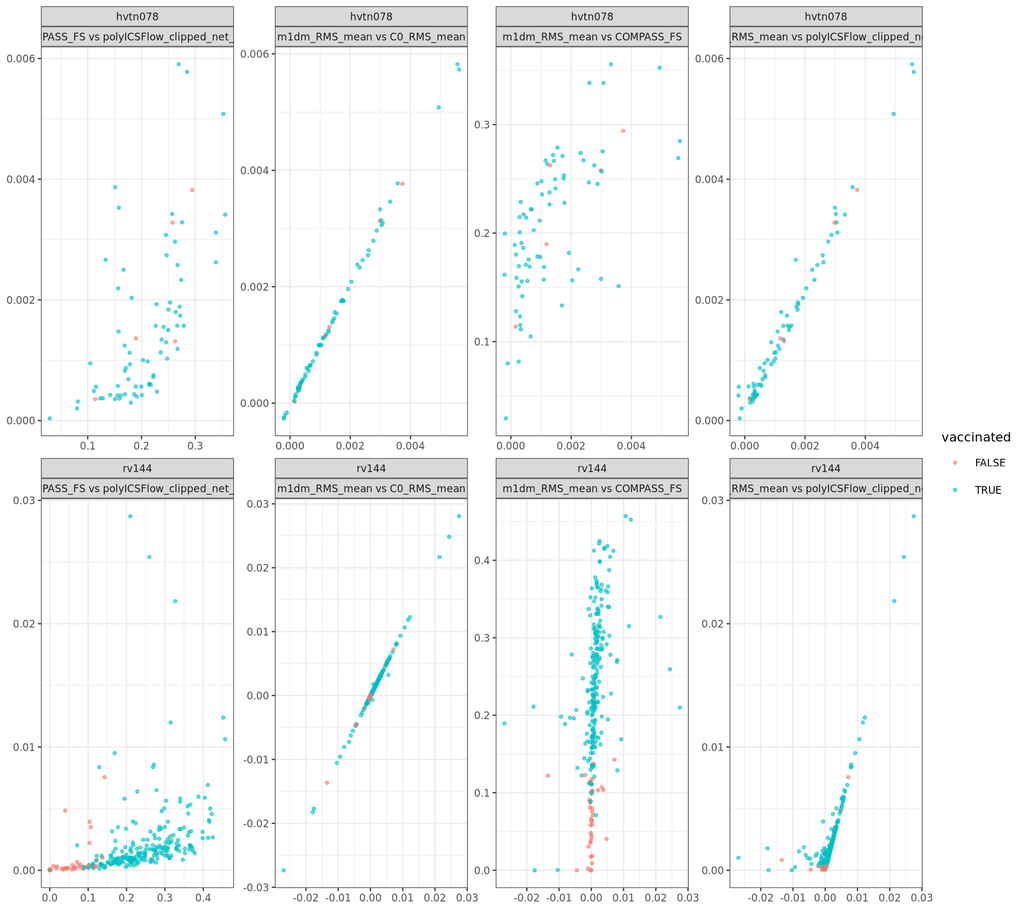

```r
pairs <- list(c("m1dm_RMS_mean", "COMPASS_FS"), c("m1dm_RMS_mean", "polyICSFlow_clipped_net_sum"), c("COMPASS_FS", "polyICSFlow_clipped_net_sum"),
              c("m1dm_RMS_mean", "C0_RMS_mean"))
map(DATASETS, \(d) {
  p <- file.path(root, RUN_DIR, d, "donor_table.tsv")
  if (!file.exists(p)) return(NULL)
  dt <- read_tsv(p, show_col_types = FALSE)
  map(pairs, \(ab) tibble(dataset = d, pair = paste(ab, collapse = " vs "), x = dt[[ab[1]]], y = dt[[ab[2]]], vaccinated = dt$vaccinated)) |> list_rbind()
}) |> list_rbind() |>
  ggplot(aes(x, y, colour = vaccinated)) +
  geom_point(alpha = 0.6, size = 0.8) +
  facet_wrap(dataset ~ pair, scales = "free", ncol = 4) +
  labs(x = NULL, y = NULL)
```

```r
read_ds("agreement.tsv") |> filter(stratum == "all") |> select(dataset, a, b, spearman) |> knitr::kable(digits = 3)
```

| dataset | a | b | spearman |
| --- | --- | --- | --- |
| rv144 | m1dm_RMS_mean | polyICSFlow_clipped_net_sum | 0.848 |
| rv144 | m1dm_RMS_mean | polyICSFlow_unclipped_net_sum | 1.000 |
| rv144 | m1dm_P_RMS_gt_eps | m1dm_RMS_mean | 0.913 |
| rv144 | m1dm_P_RMS_gt_eps | polyICSFlow_clipped_net_sum | 0.730 |
| rv144 | m1dm_P_RMS_gt_eps | polyICSFlow_unclipped_net_sum | 0.914 |
| rv144 | m1dm_CPS_mean | m1dm_RMS_mean | 0.189 |
| rv144 | m1dm_CPS_mean | m1dm_P_RMS_gt_eps | 0.273 |
| rv144 | m1dm_CPS_mean | polyICSFlow_clipped_net_sum | 0.208 |
| rv144 | m1dm_CPS_mean | polyICSFlow_unclipped_net_sum | 0.183 |
| rv144 | m1_RMS_mean | m1dm_RMS_mean | 0.790 |
| rv144 | m1_RMS_mean | m1dm_P_RMS_gt_eps | 0.823 |
| rv144 | m1_RMS_mean | m1dm_CPS_mean | 0.509 |
| rv144 | m1_RMS_mean | polyICSFlow_clipped_net_sum | 0.658 |
| rv144 | m1_RMS_mean | polyICSFlow_unclipped_net_sum | 0.789 |
| rv144 | C0_RMS_mean | m1dm_RMS_mean | 0.997 |
| rv144 | C0_RMS_mean | m1dm_P_RMS_gt_eps | 0.910 |
| rv144 | C0_RMS_mean | m1dm_CPS_mean | 0.183 |
| rv144 | C0_RMS_mean | m1_RMS_mean | 0.784 |
| rv144 | C0_RMS_mean | COMPASS_FS | 0.597 |
| rv144 | C0_RMS_mean | COMPASS_PFS | 0.483 |
| rv144 | C0_RMS_mean | COMPASS_Response | 0.597 |
| rv144 | C0_RMS_mean | polyICSFlow_clipped_net_sum | 0.841 |
| rv144 | C0_RMS_mean | polyICSFlow_unclipped_net_sum | 0.996 |
| rv144 | COMPASS_FS | m1dm_RMS_mean | 0.607 |
| rv144 | COMPASS_FS | m1dm_P_RMS_gt_eps | 0.610 |
| rv144 | COMPASS_FS | m1dm_CPS_mean | 0.637 |
| rv144 | COMPASS_FS | m1_RMS_mean | 0.724 |
| rv144 | COMPASS_FS | COMPASS_PFS | 0.924 |
| rv144 | COMPASS_FS | COMPASS_Response | 1.000 |
| rv144 | COMPASS_FS | polyICSFlow_clipped_net_sum | 0.714 |

[output cut: 60 more lines]

## Overdispersion phi

The m1dm posterior of phi is shown with the variance inflation it implies over a multinomial at the median parent count.

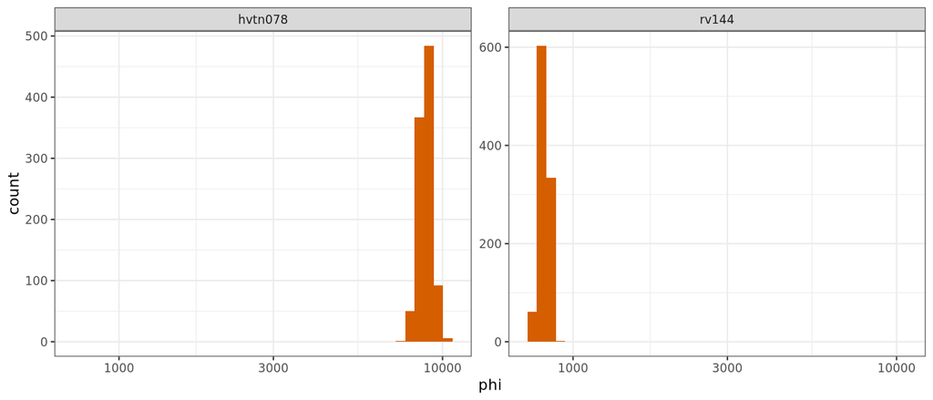

```r
read_ds("phi_draws.tsv") |>
  ggplot(aes(phi)) + geom_histogram(bins = 40, fill = "#D55E00") + scale_x_log10() + facet_wrap(~dataset, scales = "free_y")
```

```r
read_ds("phi_summary.tsv") |> knitr::kable(digits = 3)
```

| dataset | phi_mean | phi_median | phi_q05 | phi_q95 | p_phi_gt_1e6 | N_median | var_inflation_median | var_inflation_q05 | var_inflation_q95 |
| --- | --- | --- | --- | --- | --- | --- | --- | --- | --- |
| rv144 | 816.969 | 816.923 | 773.950 | 861.524 | 0 | 54905.0 | 68.126 | 64.655 | 71.848 |
| hvtn078 | 8860.894 | 8865.121 | 8195.525 | 9562.450 | 0 | 112090.5 | 13.642 | 12.721 | 14.675 |

## Model comparison by LOO

LOO compares m1dm with m1 per sample and per donor; a Pareto k above 0.7 makes an estimate unreliable, so the counts are listed.

```r
read_ds("loo_compare.tsv") |> knitr::kable(digits = 1)
```

| dataset | level | model | elpd_diff | se_diff |
| --- | --- | --- | --- | --- |
| rv144 | sample | 1 | 0.0 | 0.0 |
| rv144 | sample | 2 | -57246.3 | 5264.9 |
| rv144 | donor | 1 | 0.0 | 0.0 |
| rv144 | donor | 2 | -57192.6 | 5672.6 |
| hvtn078 | sample | 1 | 0.0 | 0.0 |
| hvtn078 | sample | 2 | -11579.8 | 1257.6 |
| hvtn078 | donor | 1 | 0.0 | 0.0 |
| hvtn078 | donor | 2 | -11561.4 | 1118.0 |

```r
read_ds("loo.tsv") |> knitr::kable(digits = 1)
```

| dataset | model | level | n_obs | elpd_loo | se_elpd | p_loo | n_pareto_k_gt_0.7 |
| --- | --- | --- | --- | --- | --- | --- | --- |
| rv144 | m1dm | sample | 524 | -27034.2 | 459.3 | 312.4 | 154 |
| rv144 | m1dm | donor | 262 | -27039.7 | 445.4 | 324.4 | 151 |
| rv144 | m1 | sample | 524 | -84280.5 | 5540.4 | 1547.3 | 472 |
| rv144 | m1 | donor | 262 | -84232.3 | 5981.6 | 1442.6 | 258 |
| hvtn078 | m1dm | sample | 152 | -8637.5 | 186.3 | 105.9 | 54 |
| hvtn078 | m1dm | donor | 76 | -8637.1 | 142.1 | 105.5 | 56 |
| hvtn078 | m1 | sample | 152 | -20217.2 | 1407.0 | 500.0 | 134 |
| hvtn078 | m1 | donor | 76 | -20198.5 | 1221.7 | 474.2 | 73 |

## Posterior predictive checks

Observed quantiles of the any-positive count across samples are set against the replicated ones (90% band over replicates), and the table gives interval coverage per statistic.

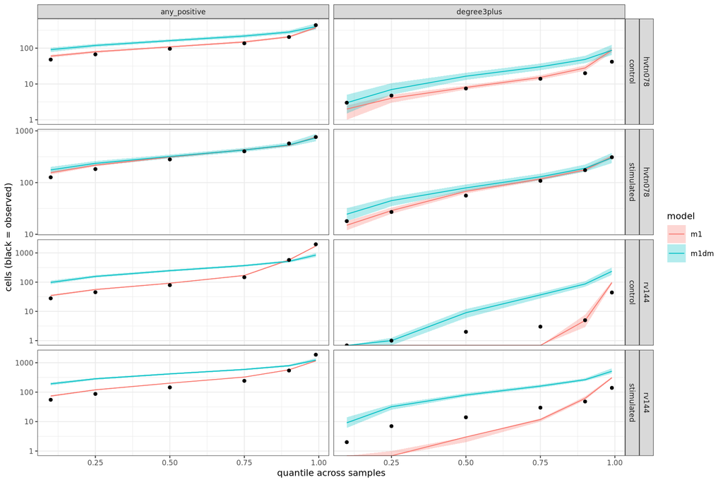

```r
read_ds("ppc_quantiles.tsv") |>
  filter(stat %in% c("any_positive", "degree3plus")) |>
  ggplot(aes(prob)) +
  geom_ribbon(aes(ymin = rep_lo, ymax = rep_hi, fill = model), alpha = 0.3) +
  geom_line(aes(y = rep_median, colour = model)) +
  geom_point(aes(y = observed)) +
  scale_y_log10() +
  facet_grid(dataset + condition ~ stat, scales = "free_y") +
  labs(x = "quantile across samples", y = "cells (black = observed)")
```

```r
read_ds("ppc_summary.tsv") |> select(dataset, model, stat, cond, coverage90, frac_ppp_extreme, obs_total, rep_total) |> knitr::kable(digits = 2)
```

| dataset | model | stat | cond | coverage90 | frac_ppp_extreme | obs_total | rep_total |
| --- | --- | --- | --- | --- | --- | --- | --- |
| rv144 | m1dm | any_positive | stimulated | 0.22 | 0.63 | 70664 | 121408.95 |
| rv144 | m1dm | any_positive | control | 0.37 | 0.52 | 54287 | 74471.15 |
| rv144 | m1dm | degree3plus | stimulated | 0.90 | 0.01 | 6222 | 30315.63 |
| rv144 | m1dm | degree3plus | control | 1.00 | 0.00 | 1118 | 7942.89 |
| rv144 | m1dm | pattern_IFNg- IL2+ TNFa- CD154+ IL4- | stimulated | 0.97 | 0.01 | 5499 | 3233.18 |
| rv144 | m1dm | pattern_IFNg- IL2+ TNFa- CD154+ IL4- | control | 1.00 | 0.00 | 929 | 2090.32 |
| rv144 | m1dm | pattern_IFNg- IL2+ TNFa+ CD154+ IL4- | stimulated | 1.00 | 0.00 | 1784 | 6102.87 |
| rv144 | m1dm | pattern_IFNg- IL2+ TNFa+ CD154+ IL4- | control | 1.00 | 0.00 | 454 | 3267.37 |
| rv144 | m1dm | pattern_IFNg- IL2- TNFa- CD154+ IL4+ | stimulated | 0.95 | 0.01 | 1462 | 3114.30 |
| rv144 | m1dm | pattern_IFNg- IL2- TNFa- CD154+ IL4+ | control | 0.91 | 0.07 | 1436 | 1126.17 |
| rv144 | m1 | any_positive | stimulated | 0.32 | 0.63 | 70664 | 71733.24 |
| rv144 | m1 | any_positive | control | 0.84 | 0.12 | 54287 | 54899.91 |
| rv144 | m1 | degree3plus | stimulated | 0.10 | 0.89 | 6222 | 6441.96 |
| rv144 | m1 | degree3plus | control | 0.22 | 0.77 | 1118 | 1239.04 |
| rv144 | m1 | pattern_IFNg- IL2+ TNFa- CD154+ IL4- | stimulated | 0.32 | 0.65 | 5499 | 4834.21 |
| rv144 | m1 | pattern_IFNg- IL2+ TNFa- CD154+ IL4- | control | 0.32 | 0.68 | 929 | 583.12 |
| rv144 | m1 | pattern_IFNg- IL2+ TNFa+ CD154+ IL4- | stimulated | 0.42 | 0.56 | 1784 | 1865.46 |
| rv144 | m1 | pattern_IFNg- IL2+ TNFa+ CD154+ IL4- | control | 0.45 | 0.55 | 454 | 569.74 |
| rv144 | m1 | pattern_IFNg- IL2- TNFa- CD154+ IL4+ | stimulated | 0.73 | 0.26 | 1462 | 1421.06 |
| rv144 | m1 | pattern_IFNg- IL2- TNFa- CD154+ IL4+ | control | 0.89 | 0.10 | 1436 | 1416.83 |
| hvtn078 | m1dm | any_positive | stimulated | 0.70 | 0.20 | 23912 | 26079.14 |
| hvtn078 | m1dm | any_positive | control | 0.59 | 0.30 | 9081 | 13450.73 |
| hvtn078 | m1dm | degree3plus | stimulated | 1.00 | 0.00 | 6216 | 7310.04 |
| hvtn078 | m1dm | degree3plus | control | 1.00 | 0.00 | 817 | 1702.63 |
| hvtn078 | m1dm | pattern_IFNg+ IL2+ TNFa+ CD154+ CD107a- | stimulated | 0.99 | 0.00 | 2594 | 4274.63 |
| hvtn078 | m1dm | pattern_IFNg+ IL2+ TNFa+ CD154+ CD107a- | control | 1.00 | 0.00 | 150 | 719.22 |
| hvtn078 | m1dm | pattern_IFNg- IL2+ TNFa+ CD154+ CD107a- | stimulated | 0.99 | 0.01 | 2342 | 2421.36 |
| hvtn078 | m1dm | pattern_IFNg- IL2+ TNFa+ CD154+ CD107a- | control | 1.00 | 0.00 | 500 | 904.41 |
| hvtn078 | m1dm | pattern_IFNg- IL2+ TNFa- CD154+ CD107a- | stimulated | 0.92 | 0.03 | 1341 | 710.90 |
| hvtn078 | m1dm | pattern_IFNg- IL2+ TNFa- CD154+ CD107a- | control | 0.97 | 0.00 | 334 | 158.39 |
| hvtn078 | m1 | any_positive | stimulated | 0.36 | 0.59 | 23912 | 25297.00 |
| hvtn078 | m1 | any_positive | control | 0.83 | 0.07 | 9081 | 9611.67 |
| hvtn078 | m1 | degree3plus | stimulated | 0.63 | 0.29 | 6216 | 6572.93 |
| hvtn078 | m1 | degree3plus | control | 0.76 | 0.14 | 817 | 1040.23 |
| hvtn078 | m1 | pattern_IFNg+ IL2+ TNFa+ CD154+ CD107a- | stimulated | 0.57 | 0.36 | 2594 | 3099.56 |
| hvtn078 | m1 | pattern_IFNg+ IL2+ TNFa+ CD154+ CD107a- | control | 0.80 | 0.17 | 150 | 252.10 |
| hvtn078 | m1 | pattern_IFNg- IL2+ TNFa+ CD154+ CD107a- | stimulated | 0.61 | 0.37 | 2342 | 2822.44 |
| hvtn078 | m1 | pattern_IFNg- IL2+ TNFa+ CD154+ CD107a- | control | 0.76 | 0.18 | 500 | 759.19 |
| hvtn078 | m1 | pattern_IFNg- IL2+ TNFa- CD154+ CD107a- | stimulated | 0.45 | 0.54 | 1341 | 616.32 |
| hvtn078 | m1 | pattern_IFNg- IL2+ TNFa- CD154+ CD107a- | control | 0.09 | 0.89 | 334 | 17.92 |

## Runtime

Wall-clock seconds per method and step; cytoJointR models use 4 CPUs and the others one.

```r
read_ds("runtime.tsv") |> select(dataset, n_donors, method, step, seconds, cpus) |> knitr::kable(digits = 1)
```

| dataset | n_donors | method | step | seconds | cpus |
| --- | --- | --- | --- | --- | --- |
| rv144 | 262 | m1dm | fit | 625.7 | 4 |
| rv144 | 262 | m1 | fit | 864.2 | 4 |
| rv144 | 262 | C0 | fit | 25.2 | 1 |
| rv144 | 262 | m1dm | scores | 62.5 | 1 |
| rv144 | 262 | m1 | scores | 17.2 | 1 |
| rv144 | 262 | C0 | scores | 42.4 | 1 |
| rv144 | 262 | COMPASS | cj_compass | 1102.0 | 1 |
| rv144 | 262 | polyICSFlow | assign_patterns | 0.0 | 1 |
| rv144 | 262 | polyICSFlow | expand_to_cells | 5.3 | 1 |
| rv144 | 262 | polyICSFlow | calcPolyfunctionality | 3.1 | 1 |
| hvtn078 | 76 | m1dm | fit | 204.9 | 4 |
| hvtn078 | 76 | m1 | fit | 207.1 | 4 |
| hvtn078 | 76 | C0 | fit | 7.8 | 1 |
| hvtn078 | 76 | m1dm | scores | 23.5 | 1 |
| hvtn078 | 76 | m1 | scores | 19.1 | 1 |
| hvtn078 | 76 | C0 | scores | 18.2 | 1 |
| hvtn078 | 76 | COMPASS | cj_compass | 231.1 | 1 |
| hvtn078 | 76 | polyICSFlow | assign_patterns | 0.1 | 1 |
| hvtn078 | 76 | polyICSFlow | expand_to_cells | 4.5 | 1 |
| hvtn078 | 76 | polyICSFlow | calcPolyfunctionality | 1.4 | 1 |